# 基金量化分析与预测报告书

量化金融系列

LiXin Wu

2019年3月28日

## 研究背景

```
 随着经济的发展和社会的进步,国民的个人财富也有了丰富的积累,这些财富急需进行有效的保值和增值服务.在此背景下,资产管理行业获得了前所未有的发展态势,迎来了**大资管时代**.在全球资产管理行业，以股票为代表的权益类资产是全球资管行业资产配置比重最大、最典型的一类资产,其次是基金.2017年由于新的**资管新规**要求未来理财产品必须完成净值化转型,理财产品的风险将逐步让渡给投资者,目前银行配置权益类资产的风险明显降低,配置意愿必然增长.
 权益类资产中股票和基金的投资具有很大的风险,作为个人投资者如何选择投资产品,实现财富有效的保值和增值呢？作为个人投资者我们比任何时候都迫切渴望提高自身产品选择能力,作者希望通过把国外金融公司先进的**量化金融技术**与**预测科学**,用通俗易懂的语言帮助投资者提高自身投资能力.
```

## 基金走势图

[figure not shown]

## 分析过去

分析过去帮助我们更好的了解这只基金,预测未来帮我们把握未来投资机会.

### 投资回报

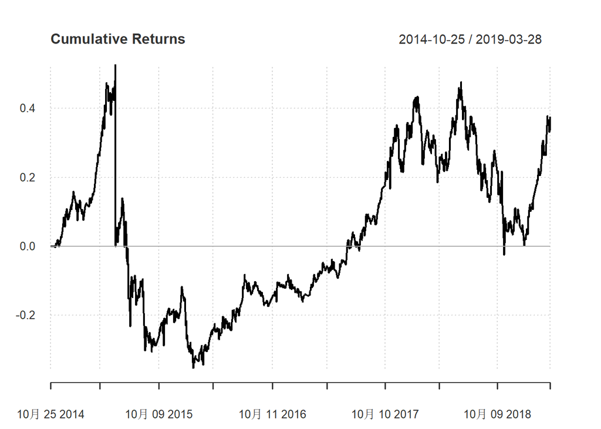

### 投资周期-季度VS月份

每一年不同季度,每个月的投资回报情况有助于我们了解投资周期和定投的周期.

[figure not shown]

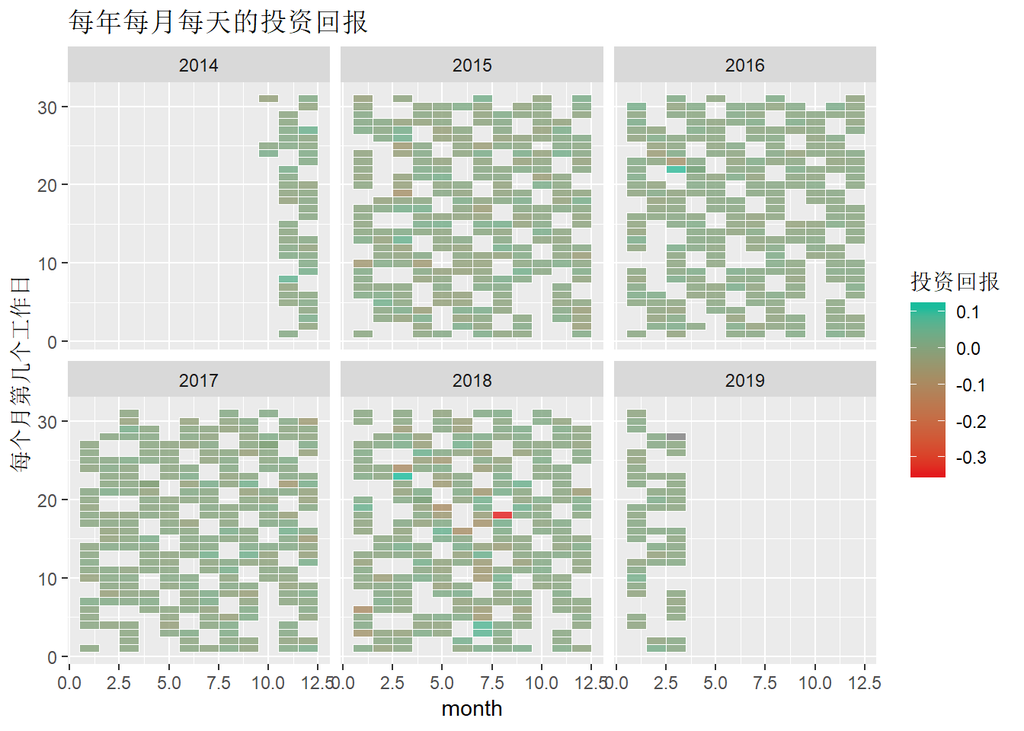

### 投资风险

一只赚钱的基金总是正的反弹比负的反弹多.正的波动产生的面积大于负的,根据面积图走势预测未来获利空间.

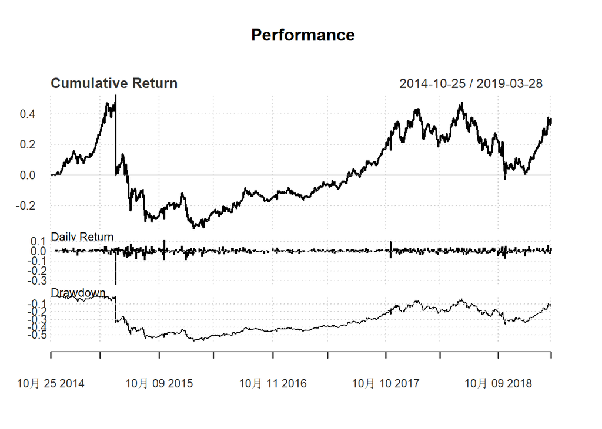

### 风险度量

风险度量,当一只基金突破边际风险线次数过多时,基本上很难赚钱.

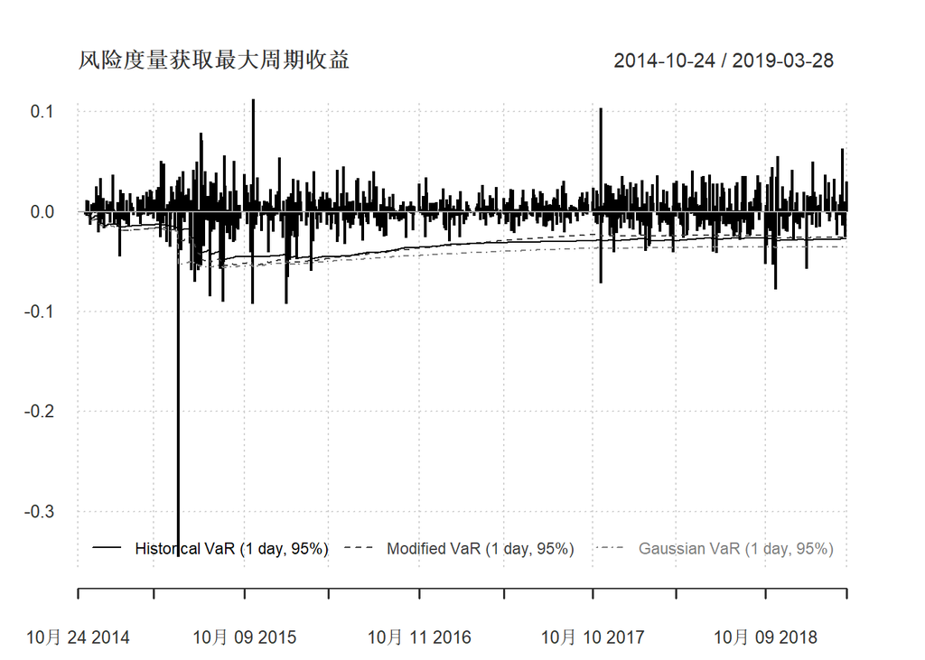

## 预测未来

### 多元聚合预测(Multiple Aggregation Prediction)

```
## Running with 4 cores
```

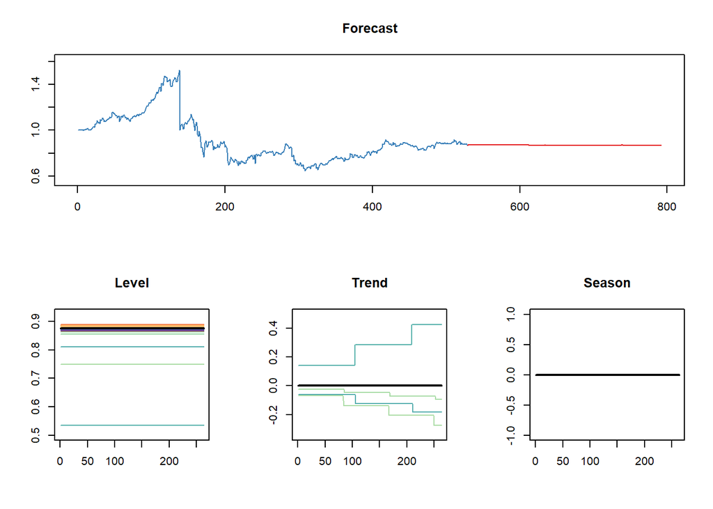

[output not shown]

[output cut: 21 more lines]

[output not shown]

## 关于作者(About me)

LiXin Wu,a young data scientist,be good at target marketing,quantitative analysis,customer management,natural language analyst,and spatial data analyst. 欢迎交流邮箱wlx521@outlook.com 个人网页https://wulixin.github.io//QuandlFinance//home.html